# Opettajien kesätyöttömyys

Juha Itkonen

26.10.2022

Seuraavassa lasketaan arvio opettajien kesätyöttömyydelle eriteltynä ammattiluokittain perustuen työnvälitystilaston työttömien työnhakijoiden määrään. Suhdanne ja trendivaihteluiden vaikutusten poistamiseksi arvio perustuu kausitasoitusmallin kuukausikomponenttien erotukseen kesäloman ja lukukausien aikana.

Haetaan työnvälitystilastosta työttömien työnhakijoiden määrä kuukausittain opettajien ammattiluokan 23 alaluokille.

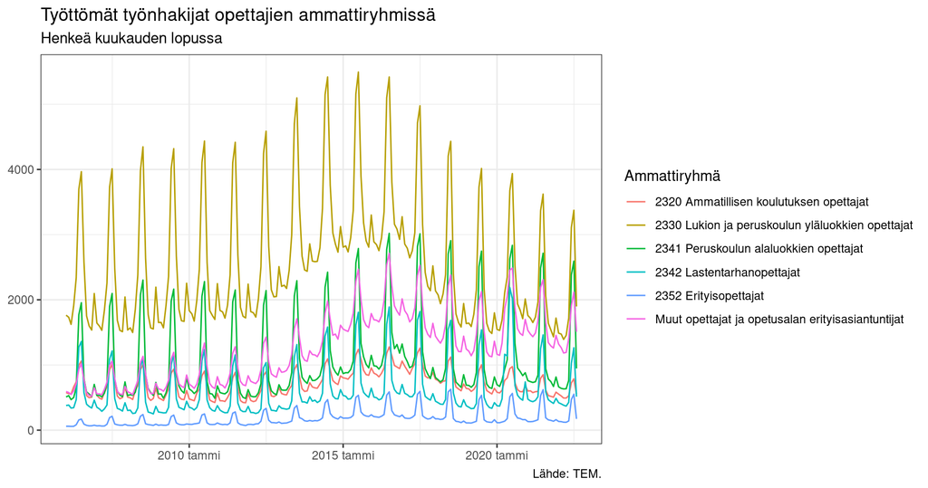

```r
u <-
  data("StatFin/tyonv/statfin_tyonv_pxt_12ti.px", tidy_time = TRUE) |>
  filter(Alue == "KOKO MAA",
         Tiedot == "Työttömät työnhakijat laskentapäivänä (lkm.)") |>
  filter(str_starts(Ammattiryhmä, "23")) |>
  replace_na(list(value = 0)) |>
  mutate(
    time = yearmonth(time),
    Ammattiryhmä =
      fct_other(
        Ammattiryhmä,
        keep = c(
          "2320 Ammatillisen koulutuksen opettajat",
          "2330 Lukion ja peruskoulun yläluokkien opettajat",
          "2341 Peruskoulun alaluokkien opettajat",
          "2342 Lastentarhanopettajat",
          "2352 Erityisopettajat"
        ),
        other_level = "Muut opettajat ja opetusalan erityisasiantuntijat"
      )
  ) |>
  group_by(Ammattiryhmä, time) |>
  summarise(value = sum(value), .groups = "drop") |>
  as_tsibble(key = Ammattiryhmä, index = time)

u |>
  ggplot(aes(time, value, color = Ammattiryhmä)) +
  geom_line() +
  labs(
    title = "Työttömät työnhakijat opettajien ammattiryhmissä",
    subtitle = "Henkeä kuukauden lopussa",
    caption = "Lähde: TEM.",
    colour = "Ammattiryhmä", x=NULL,y=NULL)
```

Testataan kolmea eri vaihtoehtoista kausitasoitusmallia. Mallit tuottavat verrattain samanlaisen hajotelman aikasarjoille (lukuunottamatta trendin erottelua koronakevään 2020 aikana).

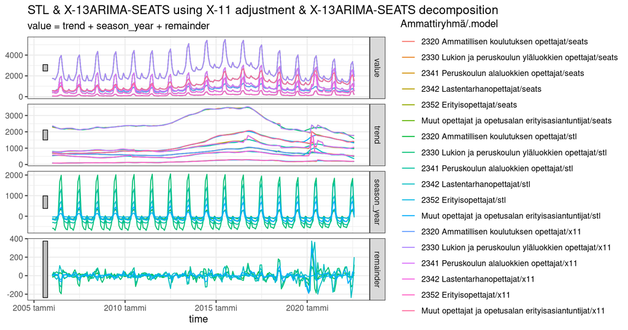

```r
seasonal_components <-
  u |>
  model(stl = STL(value ~ trend(window = 13) + season()),
        x11 = X_13ARIMA_SEATS(value ~ x11()),
        seats = X_13ARIMA_SEATS(value ~ seats())) |>
  components()

autoplot(seasonal_components)
```

STL-hajoitelman mukainen trendi:

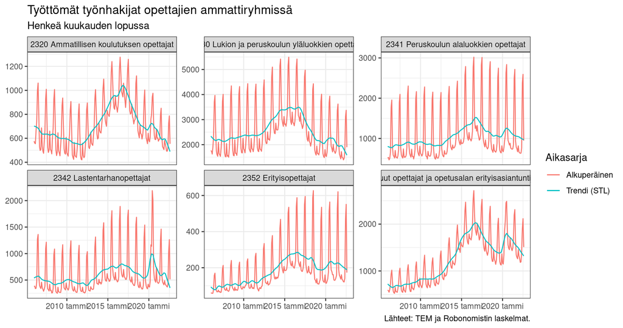

```r
seasonal_components |>
  filter(.model == "stl") |>
  ggplot(aes(x = time)) +
  geom_line(aes(y = value, color = "Alkuperäinen")) +
  geom_line(aes(y = trend, color = "Trendi (STL)")) +
  facet_wrap(~Ammattiryhmä, scales = "free_y") +
  labs(
    title = "Työttömät työnhakijat opettajien ammattiryhmissä",
    subtitle = "Henkeä kuukauden lopussa",
    caption = "Lähteet: TEM ja Robonomistin laskelmat.",
    colour = "Aikasarja", x = NULL, y = NULL
  )
```

Piirretään kausitasoitusmallin kuukausikomponentit:

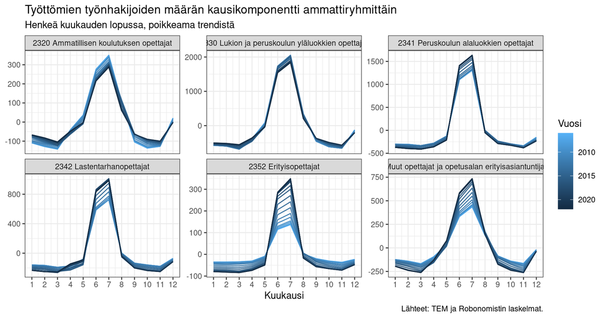

```r
seasonal_components |>
  filter(.model == "stl") |>
  as_tibble() |>
  mutate(
    Kuukausi = month(time),
    Vuosi = year(time)
  ) |>
  ggplot(aes(Kuukausi, season_year, color = Vuosi, group = Vuosi)) +
  geom_line() +
  scale_x_continuous(breaks = 1:12) +
  scale_colour_continuous(trans = "reverse") +
  facet_wrap(~Ammattiryhmä, scales = "free_y") +
  labs(
    title = "Työttömien työnhakijoiden määrän kausikomponentti ammattiryhmittäin",
    subtitle = "Henkeä kuukauden lopussa, poikkeama trendistä",
    caption = "Lähteet: TEM ja Robonomistin laskelmat.",
    y = NULL
  )
```

Kuviosta havaitaan, että kesätyöttömyys on suurimmillaan kesä- ja heinäkuun lopulla. Ammatillisen koulutuksen, lukion ja peruskoulun yläluokkien opettajilla työttömyys on pokkeavan suurta myös touko- ja elokuun lopulla. Lisäksi joulukuussa työttömyys on tavallista suurempaa.

Lisäksi havaitaan, että peruskoulun alaluokkien opettajien, lastentarhanopettajien ja erityisopettajien ammattiluokissa kesätyöttömyys on lisääntynyt viime vuosikymmenellä. Ammatillisen koulutuksen, lukion ja peruskoulun yläluokkien opettajilla kesätyöttömyys on aavistuksen vähentynyt.

Seuraavassa määritellään kesätyöttömyyden mittari kausitasoitusmallin kuukausikomponenttien avulla. Mittari suhteuttaa heinäkuun työttömyyden kausipoikkeaman lukukausien aikaisen työttömyyden erotuksena. Lukukausien normaali työttömyys on laskettu keskiarvona tammi-huhtikuun sekä syys-marraskuun kausipoikkeamista.

```r
d <- seasonal_components |>
  as_tibble() |>
  filter(.model == "stl") |>
  mutate(
    Lukuvuosi = year(time - 7),
    Lukuvuosi = paste(Lukuvuosi, Lukuvuosi+1, sep = "-\n"),
    Ammattiryhmä =
      str_replace(Ammattiryhmä, "^[:digit:]{4} ", "") |>
      fct_inorder()
  ) |>
  group_by(Ammattiryhmä, Lukuvuosi) |>
  filter(n() == 12) |>
  summarise(
    diff_lukukausi = mean(season_year[month(time) %in% c(1:4,9:11)]),
    diff_heinäkuu = season_year[month(time) == 7],
    diff_joulukuu = season_year[month(time) == 12],
    .groups = "drop"
  ) |>
  mutate(
    Kesätyöttömyys = diff_heinäkuu - diff_lukukausi,
    Joulutyöttömyys = diff_joulukuu - diff_lukukausi
  )
```

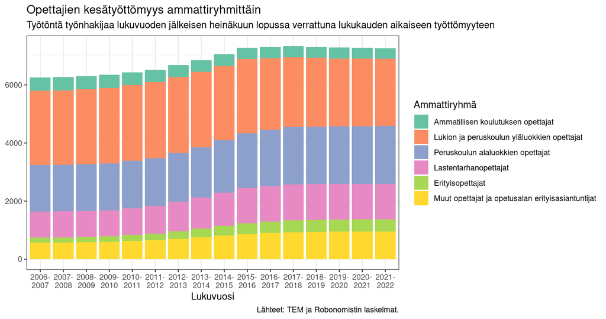

```r
d |>
  ggplot(aes(Lukuvuosi, Kesätyöttömyys, fill = Ammattiryhmä)) +
  geom_col() +
  scale_fill_brewer(palette = "Set2") +
  labs(
    title = "Opettajien kesätyöttömyys ammattiryhmittäin",
    subtitle = "Työtöntä työnhakijaa lukuvuoden jälkeisen heinäkuun lopussa verrattuna lukukauden aikaiseen työttömyyteen",
    caption = "Lähteet: TEM ja Robonomistin laskelmat.",
    y = NULL
  )
```

Opettajien kesätyöttömyys on pysynyt viime likimain muuttumattomana. Lukuvuoden 2021-2022 jälkeisenä kesänä noin 7300 opettajaa jäi kesäksi työttömäksi.

```r
d |>
  select(Ammattiryhmä, Lukuvuosi, Kesätyöttömyys) |>
  arrange(desc(Lukuvuosi)) %>%
  {
    bind_rows(., with_groups(., Lukuvuosi, summarise,
                             Ammattiryhmä = "Yhteensä",
                             across(Kesätyöttömyys, sum)
    ))
  } %>%
  mutate(Kesätyöttömyys = round(Kesätyöttömyys)) |>
  pivot_wider(names_from = "Lukuvuosi",
              values_from = Kesätyöttömyys) |>
  reactable(columns = list(Ammattiryhmä = colDef(width = 200)),
            defaultColDef = colDef(width = 70))
```

| Ammattiryhmä | 2021- 2022 | 2020- 2021 | 2019- 2020 | 2018- 2019 | 2017- 2018 | 2016- 2017 | 2015- 2016 | 2014- 2015 | 2013- 2014 | 2012- 2013 | 2011- 2012 | 2010- 2011 | 2009- 2010 | 2008- 2009 | 2007- 2008 | 2006- 2007 |
| --- | --- | --- | --- | --- | --- | --- | --- | --- | --- | --- | --- | --- | --- | --- | --- | --- |
| Ammatillisen koulutuksen opettajat | 367 | 368 | 370 | 374 | 379 | 387 | 395 | 397 | 399 | 409 | 419 | 434 | 447 | 454 | 459 | 462 |
| Lukion ja peruskoulun yläluokkien opettajat | 2314 | 2327 | 2342 | 2372 | 2408 | 2477 | 2543 | 2568 | 2594 | 2612 | 2626 | 2614 | 2599 | 2583 | 2567 | 2561 |
| Peruskoulun alaluokkien opettajat | 2001 | 1997 | 1994 | 1986 | 1976 | 1933 | 1887 | 1805 | 1728 | 1684 | 1641 | 1632 | 1622 | 1615 | 1609 | 1607 |
| Lastentarhanopettajat | 1210 | 1214 | 1218 | 1230 | 1239 | 1232 | 1221 | 1152 | 1084 | 1014 | 947 | 919 | 893 | 894 | 894 | 894 |
| Erityisopettajat | 423 | 421 | 419 | 413 | 406 | 386 | 364 | 329 | 295 | 262 | 230 | 208 | 189 | 181 | 174 | 171 |
| Muut opettajat ja opetusalan erityisasiantuntijat | 951 | 948 | 945 | 938 | 928 | 901 | 869 | 809 | 752 | 702 | 656 | 625 | 595 | 584 | 573 | 569 |
| Yhteensä | 7265 | 7276 | 7287 | 7313 | 7336 | 7315 | 7279 | 7061 | 6852 | 6683 | 6519 | 6432 | 6346 | 6310 | 6276 | 6264 |

## Lisätietoja

### Joulutyöttömyys

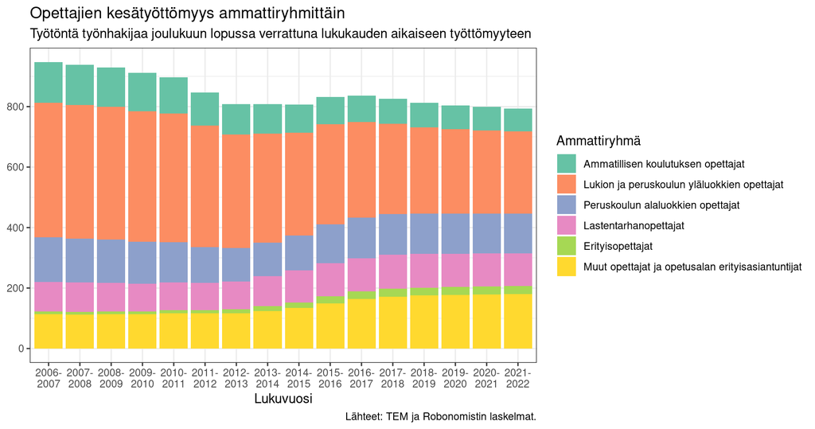

```r
d |>
  ggplot(aes(Lukuvuosi, Joulutyöttömyys, fill = Ammattiryhmä)) +
  geom_col() +
  scale_fill_brewer(palette = "Set2") +
  scale_y_continuous(breaks = seq(0, 1000, by = 200)) +
  labs(
    title = "Opettajien kesätyöttömyys ammattiryhmittäin",
    subtitle = "Työtöntä työnhakijaa joulukuun lopussa verrattuna lukukauden aikaiseen työttömyyteen",
    caption = "Lähteet: TEM ja Robonomistin laskelmat.",
    y = NULL
  )
```

### Työttömien työnhakijoiden määrä

```r
seasonal_components |>
  as_tibble() |>
  filter(.model == "stl") |>
  mutate(
    Lukuvuosi = year(time - 7),
    Lukuvuosi = paste(Lukuvuosi, Lukuvuosi+1, sep = "-\n"),
    Ammattiryhmä =
      str_replace(Ammattiryhmä, "^[:digit:]{4} ", "") |>
      fct_inorder()
  ) |>
  group_by(Ammattiryhmä, Lukuvuosi) |>
  filter(n() == 12) |>
  summarise(
    `Lukukauden keskiarvo` = mean(value[month(time) %in% c(1:4,9:11)]),
    Heinäkuu = value[month(time) == 7],
    Joulukuu = value[month(time) == 12],
    .groups = "drop"
  ) |>
  with_groups(Lukuvuosi, summarize,
              across(-Ammattiryhmä, sum)
              ) |>
  mutate(across(-Lukuvuosi, round)) |>
  reactable(defaultPageSize = 20)
```

| Lukuvuosi | Lukukauden keskiarvo | Heinäkuu | Joulukuu |
| --- | --- | --- | --- |
| 2006- 2007 | 3672 | 9604 | 4671 |
| 2007- 2008 | 3609 | 10116 | 4624 |
| 2008- 2009 | 3672 | 10011 | 4748 |
| 2009- 2010 | 3985 | 10450 | 5051 |
| 2010- 2011 | 3874 | 10170 | 4798 |
| 2011- 2012 | 3888 | 10422 | 4709 |
| 2012- 2013 | 4660 | 11796 | 5313 |
| 2013- 2014 | 5726 | 12969 | 6302 |
| 2014- 2015 | 6710 | 14335 | 7364 |
| 2015- 2016 | 7156 | 14909 | 8073 |

[output cut: 6 more lines]